# Bertrand, Duflo, Mullainathan (2004)

Jim Flynn

October 7, 2026

## How Much Should We Trust DiD Estimates?

- DiD had become common way to evaluate policy
- Most focused exoegeneity of policy adoption
  - Why is this important?
- This paper focuses on the standard errors of DiD estimates
  - What are the implications of bad standard errors?

## Table I - Assessing the potential problem

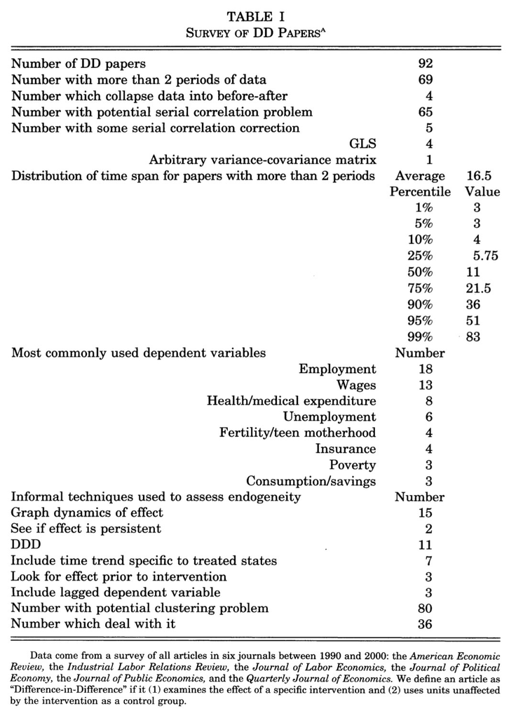

## Issue

- It is almost impossible to tell whether serial correlation is a problem for any one paper
  - Maybe it exists but we can’t tell if it drives the result
  - So what do they do?

## Placebo estimates

- Using CPS data on women’s wages from 1979-1999
- Look at earnings employment status, education
- Randomly create fake laws and treatment years
- Treat year randomly drawn from 1985-1995
- 25 states randomly assigned to be treated
- Run DiD repeatedly to estimate the effect of ‘laws’
  - Why do this?
  - What do we expect to happen?

## Specification

$$Y_{ist} = A_s + B_t + cX_{ist} + \beta
I_{st} + \epsilon_{ist}$$

- $Y$ is outcome
- $A_s$ is state FE
- $B_t$ is year FE
- $X_{ist}$ are individual controls
- $I_{st}$ is treatment indicator

## Table II - Which one did we do?

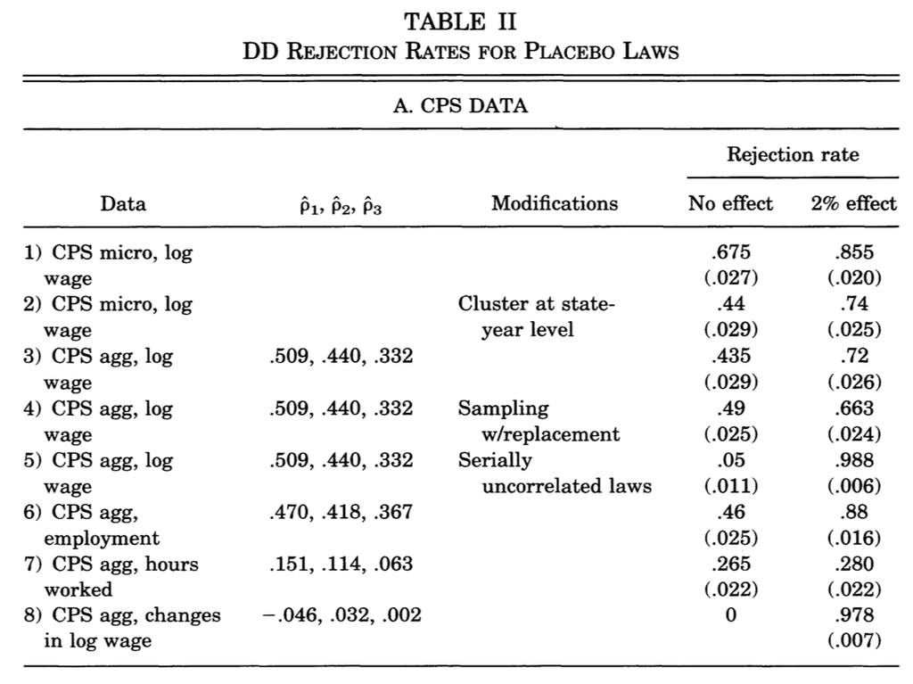

## Ok so we have a problem

- 60 percent of ‘significant’ estimates are in the 1-2% range
- If you ever read applied papers, this should freak you out
  - What can we do?

## Table III Varying N and T

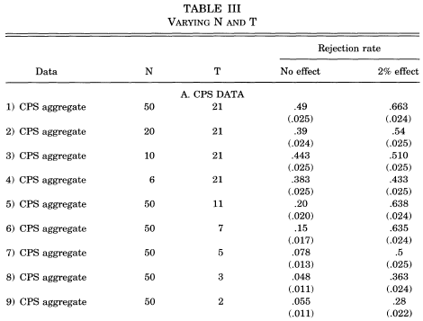

## Table IV - Parametric solutions

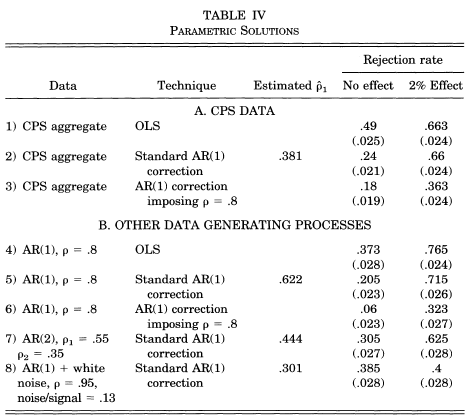

## Block bootstrap

- We want to get a picture of the sampling variance
- Bootstrapping does this in general
  - What is bootstrapping?
  - Sampling with replacement from original data
  - Here we are doing this with blocks (states)

## Table V

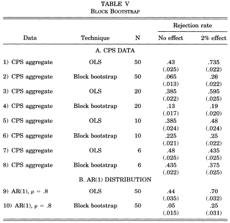

Work great….with lots of states.

## Ignoring time series information

- Big part of the problem is having many periods
- Can aggregate data into a pre and post period
- Only works when all laws passed simultaneously
  - Residual aggregation solution

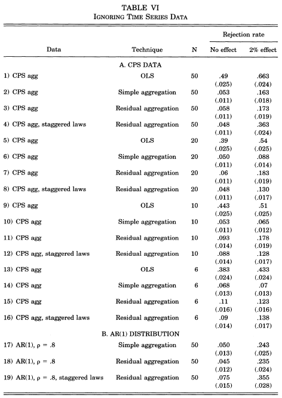

## Takeaways

- The standard DiD estimate can have serious issues
- Need to be thoughtful about standard errors
  - And potential issues
- We will see after the midterm that a lot has changed and a lot has stayed the same